# Prática Ciência de Dados no R

Prática de ciência de dados no R em que serão respondidas 12 perguntas a respeito dos dados de vendas de eletrônicos ao longo de 12 meses. O arquivo se chama all_data.

Cada linha do data frame representa o item de uma compra que pode ou não conter mais itens; temos também a data e hora da compra, o valor do item e a quantidade comprada, além do endereço completo. Isso significa que linhas diferentes com o mesmo ID representam diferentes produtos que foram comprados simultâneamente, com entrega para um único endereço. Além disso, não deve haver linhas idênticas.

### Limpeza e organização

Vamos inicialmente ler e analisar o data frame e o conteúdo de suas colunas

```r
library(dplyr)
library(ggplot2)
library(dygraphs)
library(tidyverse)
library(hrbrthemes)
library(forcats)
library(viridis)

all_data <- read.csv("C:/Users/Gisele/Desktop/Pandas-Data-Science-Tasks-master/all_data.csv", stringsAsFactors=T)
```

```r
head(all_data,n=30)
```

|  | Order.ID | Product | Quantity.Ordered | Price.Each | Order.Date | Purchase.Address |
| --- | --- | --- | --- | --- | --- | --- |
| 1 | 176558 | USB-C Charging Cable | 2 | 11.95 | 04/19/19 08:46 | 917 1st St, Dallas, TX 75001 |
| 2 |  |  |  |  |  |  |
| 3 | 176559 | Bose SoundSport Headphones | 1 | 99.99 | 04/07/19 22:30 | 682 Chestnut St, Boston, MA 02215 |
| 4 | 176560 | Google Phone | 1 | 600 | 04/12/19 14:38 | 669 Spruce St, Los Angeles, CA 90001 |
| 5 | 176560 | Wired Headphones | 1 | 11.99 | 04/12/19 14:38 | 669 Spruce St, Los Angeles, CA 90001 |
| 6 | 176561 | Wired Headphones | 1 | 11.99 | 04/30/19 09:27 | 333 8th St, Los Angeles, CA 90001 |
| 7 | 176562 | USB-C Charging Cable | 1 | 11.95 | 04/29/19 13:03 | 381 Wilson St, San Francisco, CA 94016 |
| 8 | 176563 | Bose SoundSport Headphones | 1 | 99.99 | 04/02/19 07:46 | 668 Center St, Seattle, WA 98101 |
| 9 | 176564 | USB-C Charging Cable | 1 | 11.95 | 04/12/19 10:58 | 790 Ridge St, Atlanta, GA 30301 |
| 10 | 176565 | Macbook Pro Laptop | 1 | 1700 | 04/24/19 10:38 | 915 Willow St, San Francisco, CA 94016 |

[output cut: 20 more lines]

```r
summary(all_data)
```

```
##      Order.ID                          Product              Quantity.Ordered
##          :   545   USB-C Charging Cable    :21903   1               :168552
##  Order ID:   355   Lightning Charging Cable:21658   2               : 13324
##  160873  :     5   AAA Batteries (4-pack)  :20641   3               :  2920
##  165665  :     4   AA Batteries (4-pack)   :20577   4               :   806
##  178158  :     4   Wired Headphones        :18882                   :   545
##  193511  :     4   Apple Airpods Headphones:15549   Quantity Ordered:   355
##  (Other) :185933   (Other)                 :67640   (Other)         :   348
##    Price.Each             Order.Date
##  11.95  :21903                 :   545
##  14.95  :21658   Order Date    :   355
##  2.99   :20641   12/15/19 20:16:     8
##  3.84   :20577   04/02/19 13:24:     7
##  11.99  :18882   10/30/19 21:28:     7
##  150    :15450   12/11/19 13:24:     7
##  (Other):67739   (Other)       :185921
##                                Purchase.Address
##                                        :   545
##  Purchase Address                      :   355
##  193 Forest St, San Francisco, CA 94016:     9
##  223 Elm St, Los Angeles, CA 90001     :     8
##  279 Sunset St, San Francisco, CA 94016:     8
##  176 North St, San Francisco, CA 94016 :     7
##  (Other)                               :185918
```

A função *summary* nos mostra alguns problemas: todas as variáveis foram interpretadas como fatores, há linhas completamente vazias e outras preenchidas com o nome da respectiva variável.

Vamos primeiro remover as linhas vazias, em seguida as linhas preenchidas com o nome da coluna.

```r
#remove linhas vazias
dados = all_data[!apply(all_data == "", 1, all), ]

#remove linhas cujo valor da coluna Order.ID seja 'Order ID'
dados = subset(dados, Order.ID != 'Order ID')
```

A partir de agora, trabalharemos apenas com o data frame ‘dados’

As variáveis ‘Quantity.Ordered’ e ‘Price Each’ foram interpretados como fatores. Vamos converter para o formato numérico, mas antes, precisamos converter para o formato ‘character’ do R

```r
dados$Quantity.Ordered = as.numeric(as.character(dados$Quantity.Ordered))
dados$Price.Each = as.numeric(as.character(dados$Price.Each))
```

Agora que os dados estão prontos para o uso, vamos chamar novamente a função *summary*

```r
summary(dados)
```

```
##     Order.ID                          Product      Quantity.Ordered
##  160873 :     5   USB-C Charging Cable    :21903   Min.   :1.000
##  165665 :     4   Lightning Charging Cable:21658   1st Qu.:1.000
##  178158 :     4   AAA Batteries (4-pack)  :20641   Median :1.000
##  193511 :     4   AA Batteries (4-pack)   :20577   Mean   :1.124
##  194253 :     4   Wired Headphones        :18882   3rd Qu.:1.000
##  196615 :     4   Apple Airpods Headphones:15549   Max.   :9.000
##  (Other):185925   (Other)                 :66740
##    Price.Each               Order.Date
##  Min.   :   2.99   12/15/19 20:16:     8
##  1st Qu.:  11.95   04/02/19 13:24:     7
##  Median :  14.95   10/30/19 21:28:     7
##  Mean   : 184.40   12/11/19 13:24:     7
##  3rd Qu.: 150.00   01/17/19 21:54:     6
##  Max.   :1700.00   02/06/19 11:14:     6
##                    (Other)       :185909
##                                Purchase.Address
##  193 Forest St, San Francisco, CA 94016:     9
##  223 Elm St, Los Angeles, CA 90001     :     8
##  279 Sunset St, San Francisco, CA 94016:     8
##  176 North St, San Francisco, CA 94016 :     7
##  197 Center St, San Francisco, CA 94016:     7
##  284 Walnut St, San Francisco, CA 94016:     7
##  (Other)                               :185904
```

```r
summary(as.factor(dados$Product))
```

```
##                                          20in Monitor
##                          0                       4101
##     27in 4K Gaming Monitor           27in FHD Monitor
##                       6230                       7507
##     34in Ultrawide Monitor      AA Batteries (4-pack)
##                       6181                      20577
##     AAA Batteries (4-pack)   Apple Airpods Headphones
##                      20641                      15549
## Bose SoundSport Headphones              Flatscreen TV
##                      13325                       4800
##               Google Phone                     iPhone
##                       5525                       6842
##                   LG Dryer         LG Washing Machine
##                        646                        666
##   Lightning Charging Cable         Macbook Pro Laptop
##                      21658                       4724
##                    Product            ThinkPad Laptop
##                          0                       4128
##       USB-C Charging Cable            Vareebadd Phone
##                      21903                       2065
##           Wired Headphones
##                      18882
```

```r
head(summary(as.factor(dados$Purchase.Address)))
```

```
## 193 Forest St, San Francisco, CA 94016      223 Elm St, Los Angeles, CA 90001
##                                      9                                      8
## 279 Sunset St, San Francisco, CA 94016  176 North St, San Francisco, CA 94016
##                                      8                                      7
## 197 Center St, San Francisco, CA 94016 284 Walnut St, San Francisco, CA 94016
##                                      7                                      7
```

```r
paste('Número total de produtos vendidos:',sum(dados$Quantity.Ordered))
```

```
## [1] "Número total de produtos vendidos: 209079"
```

Alguns resultados interessantes:

O item mais barato custou 2.99, e o mais caro, 1700 dólares.

Podemos ver a quantidade de endereços diferentes registrada

```r
paste('Número de endereços:', nlevels(as.factor(dados$Purchase.Address)))
```

```
## [1] "Número de endereços: 140789"
```

E a distribuição do número de unidade por produto.

```r
value=as.factor(dados$Quantity.Ordered)
value =summary(value)
value
```

```
##      1      2      3      4      5      6      7      8      9
## 168552  13324   2920    806    236     80     24      5      3
```

A maioria absoluta dos produtos foi comprada como item único (168552), enquanto dois itens iguais foram pedidos em apenas 13324 vezes, caindo ainda mais para 2920 para 3 itens iguais na mesma compra.

### Qual foi o melhor mês de vendas

Começaremos obtendo uma coluna com o valor total de cada linha

```r
dados$Value = dados$Quantity.Ordered * dados$Price.Each
```

Precisamos extrair o mês de cada venda e associar à uma nova coluna

Como o mês é indicado pelos primeiros dois caracteres da data de compra, extraímos esses caracteres com a função *substr(x,start,stop)*

```r
dados$month = substr(as.character(dados$Order.Date), start=1,stop=2)

head(dados)
```

|  | Order.ID | Product | Quantity.Ordered | Price.Each | Order.Date | Purchase.Address | Value | month |
| --- | --- | --- | --- | --- | --- | --- | --- | --- |
| 1 | 176558 | USB-C Charging Cable | 2 | 11.95 | 04/19/19 08:46 | 917 1st St, Dallas, TX 75001 | 23.90 | 04 |
| 3 | 176559 | Bose SoundSport Headphones | 1 | 99.99 | 04/07/19 22:30 | 682 Chestnut St, Boston, MA 02215 | 99.99 | 04 |
| 4 | 176560 | Google Phone | 1 | 600.00 | 04/12/19 14:38 | 669 Spruce St, Los Angeles, CA 90001 | 600.00 | 04 |
| 5 | 176560 | Wired Headphones | 1 | 11.99 | 04/12/19 14:38 | 669 Spruce St, Los Angeles, CA 90001 | 11.99 | 04 |
| 6 | 176561 | Wired Headphones | 1 | 11.99 | 04/30/19 09:27 | 333 8th St, Los Angeles, CA 90001 | 11.99 | 04 |
| 7 | 176562 | USB-C Charging Cable | 1 | 11.95 | 04/29/19 13:03 | 381 Wilson St, San Francisco, CA 94016 | 11.95 | 04 |

Agora, podemos obter o valor total vendido em cada mês e salvar num novo date frame. É importante lembrar que as vendas do primeiro dia de 2020 também foram registradas e serão contabilizadas juntamente com as vendas de janeiro de 2019.

```r
venda.mes=aggregate(Value ~month,
                    data=dados,FUN=sum)


venda.mes
```

| month | Value |
| --- | --- |
| 01 | 1822257 |
| 02 | 2202022 |
| 03 | 2807100 |
| 04 | 3390670 |
| 05 | 3152607 |
| 06 | 2577802 |
| 07 | 2647776 |
| 08 | 2244468 |
| 09 | 2097560 |
| 10 | 3736727 |

[output cut: 2 more lines]

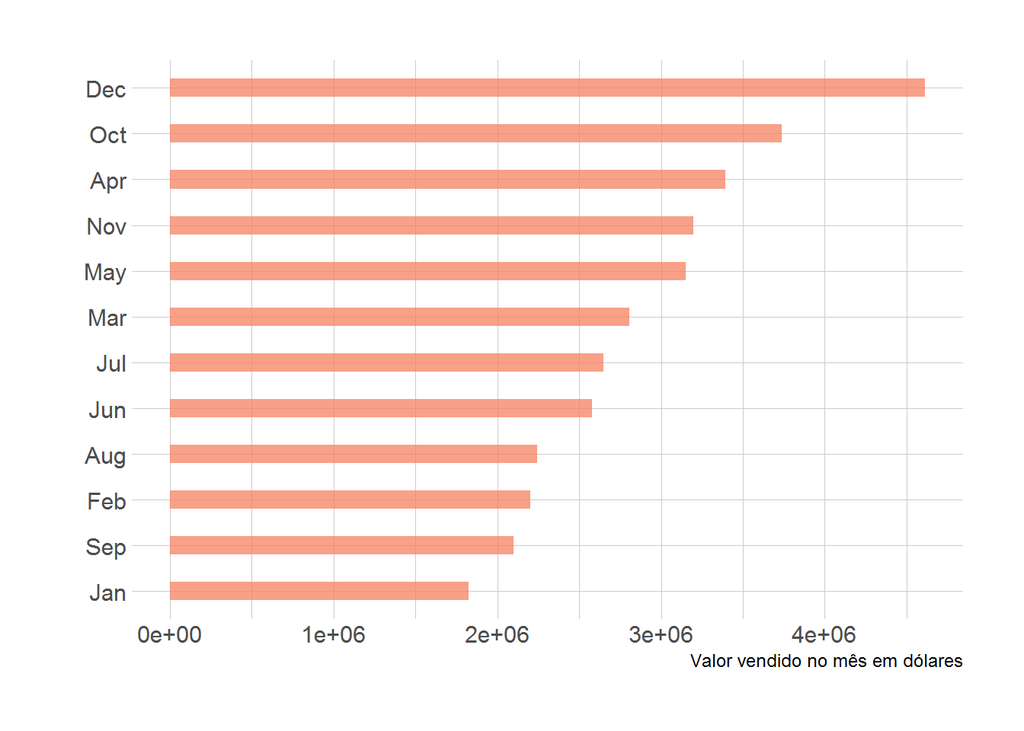

```r
venda.mes$month=month.abb

library(forcats)

#reordena em ordem decrescente com o pacote forcats. A função mutate é do pacote dplyr
venda.mes %>%
   mutate(month = fct_reorder(month, Value)) %>%

 ggplot( aes(x=month, y=Value)) +
    geom_bar(stat="identity", fill="#f68060", alpha=.75, width=.4) +
    coord_flip() +
    ylab("Valor vendido no mês em dólares") +
    xlab("")+
    theme_ipsum(base_family = "Calibri")
```

### Em que horas do dia foram registradas mais vendas?

Vamos extrair o horário da venda de maneira similar a como fizemos com a data. Para isso, basta notar que a hora da compra são os caracteres 10 e 11 das célula de Order.Date

```r
dados$Hour = substr(as.character(dados$Order.Date), start=10,stop=11)
```

E então podemos verificar a relação entre o valor das vendas e a hora ou a quantidade de itens vendidos e a hora.

```r
#Valor total vendido para cada hora do dia
venda.hora=aggregate(Value ~Hour,
                    data=dados,FUN=sum)


venda.hora
```

| Hour | Value |
| --- | --- |
| 00 | 713721.3 |
| 01 | 460866.9 |
| 02 | 234851.4 |
| 03 | 145757.9 |
| 04 | 162661.0 |
| 05 | 230679.8 |
| 06 | 448113.0 |
| 07 | 744854.1 |
| 08 | 1192349.0 |
| 09 | 1639030.6 |

[output cut: 14 more lines]

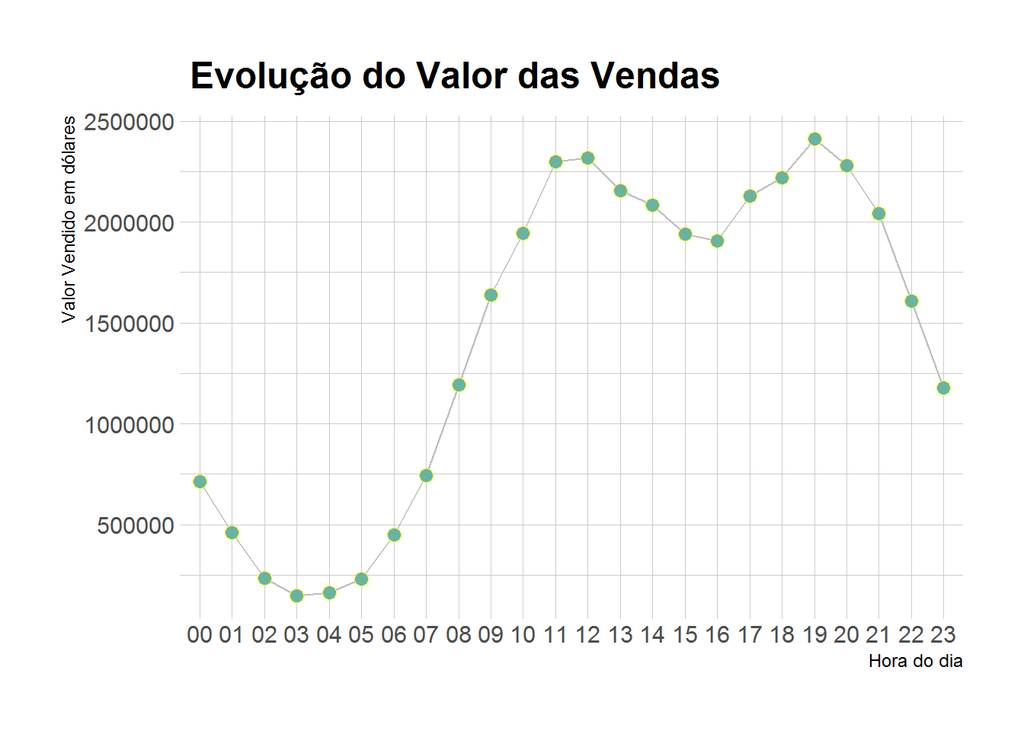

```r
a=venda.hora %>%

 ggplot( aes(x=Hour, y=Value, group=1)) +
   geom_line( color="grey") +
   geom_point(shape=21, color="yellow", fill="#69b3a2", size=3) +
   theme_ipsum(base_family = "Calibri") +
    labs(
    x = "Hora do dia",
    y = "Valor Vendido em dólares",
    title = " Evolução do Valor das Vendas"

  )


a
```

Também podemos observar a evolução das vendas de cada produto ao longo do dia:

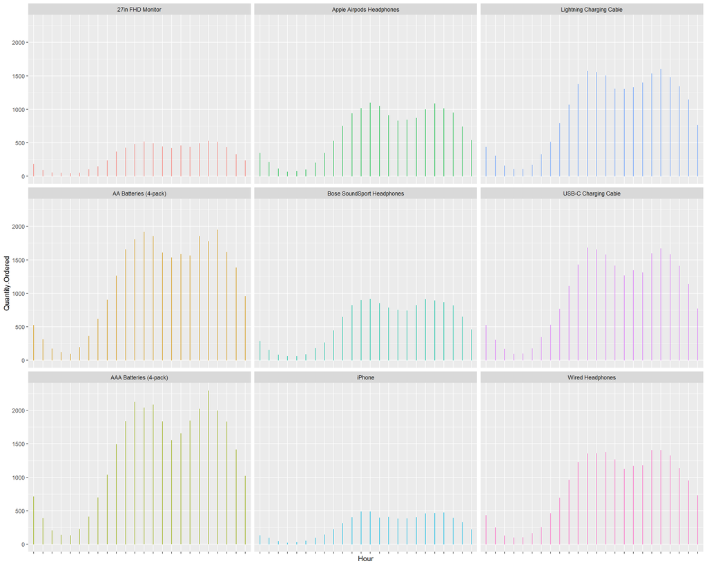

```r
dados3 =dados %>%

   filter(Product %in% c("AAA Batteries (4-pack)","iPhone","Apple Airpods Headphones" ,"Lightning Charging Cable","Wired Headphones" ,"Bose SoundSport Headphones","AA Batteries (4-pack)","USB-C Charging Cable","27in FHD Monitor"))


dados3 %>%
ggplot( aes(x=Hour, y=Quantity.Ordered, color=Product  )) +
  geom_area() +
  facet_wrap(~Product , dir="v")  +
  theme(legend.position="none",axis.text.x = element_blank())
```

**Conclusão**

Compras no site foram realizadas com mais frequência entre 10h e 21h, atingindo picos as 12 e também as 19h. Os produtos não apresentam divergência quanto à isso: todos apresentaram o mesmo formato de distribuição, variando apenas na quantidade, que manteve a proporção ao longo de todo o dia.

### Quais dias do mês venderam mais?

Vamos agora utilizar o pacote lubridate que funciona da seguinte forma:

time = c(“2019-04-17”, “2019-01-23”) - **isto está no formato character**

ymd(time) - **isto está em formato de data**

A vantagem do formato de data do R, é que o ggplot o reconhece automaticamente. Vamos então extrair a data das compras.

```r
library(lubridate)

#usa a função mdy do pacote lubridate para converter a data da compra que é representda pelos characteres de 1 a 8 de Order.Date
dados$Date = mdy(substr(as.character(dados$Order.Date), start=1,stop=8))

str(dados)
```

```
## 'data.frame':    185950 obs. of  10 variables:
##  $ Order.ID        : Factor w/ 178439 levels "","141234","141235",..: 35326 35327 35328 35328 35329 35330 35331 35332 35333 35334 ...
##  $ Product         : Factor w/ 21 levels "","20in Monitor",..: 19 9 11 21 21 19 9 19 16 21 ...
##  $ Quantity.Ordered: num  2 1 1 1 1 1 1 1 1 1 ...
##  $ Price.Each      : num  11.9 100 600 12 12 ...
##  $ Order.Date      : Factor w/ 142397 levels "","01/01/19 03:07",..: 37728 32585 34655 34655 42698 42337 29984 34552 40011 32800 ...
##  $ Purchase.Address: Factor w/ 140789 levels "","1 11th St, Atlanta, GA 30301",..: 127922 91288 89200 89200 36627 44206 88980 108150 127743 114309 ...
##  $ Value           : num  23.9 100 600 12 12 ...
##  $ month           : chr  "04" "04" "04" "04" ...
##  $ Hour            : chr  "08" "22" "14" "14" ...
##  $ Date            : Date, format: "2019-04-19" "2019-04-07" ...
```

Note que a nova variável ‘Date’ é do tipo Date, e não factor ou character.

Usando a função *xts* do pacote xts, criamos um novo data frame que é indexado pelas datas. Em segida, usamos *apply.daily* do mesmo pacote para obter a soma das vendas de cada dia.

```r
library(xts)

venda.data = xts(dados[, "Value"], order.by = dados$Date)

venda.data = apply.daily(venda.data, sum)
```

**Observação:** podemos obter o valor de venda de cada mês de uma forma mais precisa agora que temos o pacote xts

```r
apply.monthly(venda.data,sum)
```

```
##                  [,1]
## 2019-01-31 1813586.44
## 2019-02-28 2202022.42
## 2019-03-31 2807100.38
## 2019-04-30 3390670.24
## 2019-05-31 3152606.75
## 2019-06-30 2577802.26
## 2019-07-31 2647775.76
## 2019-08-31 2244467.88
## 2019-09-30 2097560.13
## 2019-10-31 3736726.88
## 2019-11-30 3199603.20
## 2019-12-31 4613443.34
## 2020-01-01    8670.29
```

```r
library(dygraphs)
dygraph(apply.monthly(venda.data,sum), main = 'Evolução das vendas por mês')
```

[interactive chart not shown]

Podemos também fazer um gráfico interativo da distribuição da evolução das vendas por dia.

[interactive chart not shown]

### Qual cidade vendeu mais?

Precisamos extrair a cidade e o estado pois há duas cidade com o mesmo nome em estados diferentes. Depois, basta aplicar a função *aggregate* novamente.

Agora, não é possível saber exatamente quais serão os índices a serem selecionados, pois os endereços não tem um formato padrão como hora e data. Então, vamos separar a string do endereço primeiro, utilizando a vírgula como separador para então selecionarmos a cidade e o estado.

```r
#strsplit retorna uma lista
city=  strsplit(as.character(dados$Purchase.Address), split = ','); city[1]; city[2]
```

```
## [[1]]
## [1] "917 1st St" " Dallas"    " TX 75001"
```

```
## [[1]]
## [1] "682 Chestnut St" " Boston"         " MA 02215"
```

```r
#convertendo para o formato vetor e selecionando apenas a cidade e o estado (a cidade é o segundo elemento e o estado são os caracteres 2 e 3 do terceiro elemento de cada objeto da lista)
city = unlist(lapply(city, function(x)  paste(x[2],substr(x[3],start=2,stop=3))))

paste("Cada elemento do vetor city contem a cidade e o estado de cada compra:")
```

```
## [1] "Cada elemento do vetor city contem a cidade e o estado de cada compra:"
```

```r
paste("City[1]:",city[1])
```

```
## [1] "City[1]:  Dallas TX"
```

```r
dados$City = city
```

Agora que temos a coluna com cidade e estado, usamos a função *aggregate* novamente

```r
venda.cidade = aggregate(Value ~ City, dados,  sum)

venda.cidade
```

| City | Value |
| --- | --- |
| Atlanta GA | 2795498.6 |
| Austin TX | 1819581.8 |
| Boston MA | 3661642.0 |
| Dallas TX | 2767975.4 |
| Los Angeles CA | 5452570.8 |
| New York City NY | 4664317.4 |
| Portland ME | 449758.3 |
| Portland OR | 1870732.3 |
| San Francisco CA | 8262203.9 |
| Seattle WA | 2747755.5 |

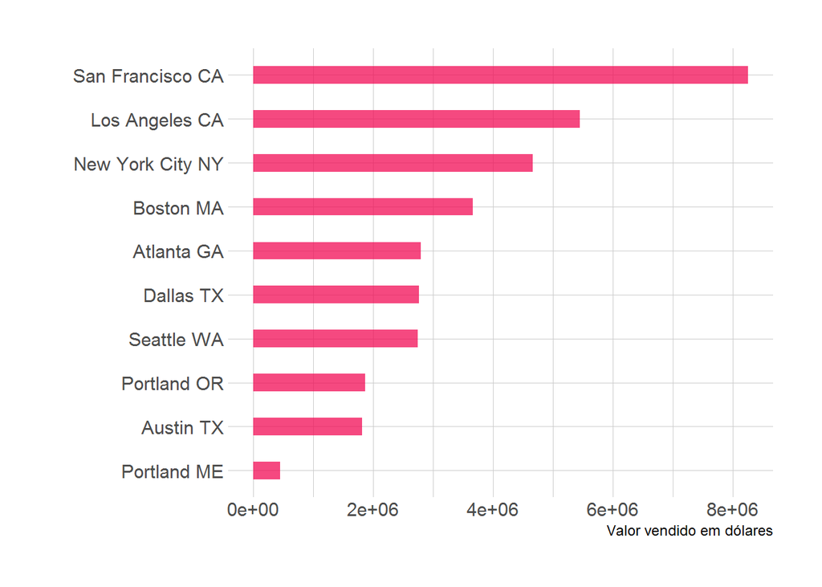

```r
venda.cidade %>%
   mutate(City = fct_reorder(City, Value)) %>%

ggplot( aes(x=City, y=Value)) +
    geom_bar(stat="identity", fill="#F10C55", alpha=.75, width=.4) +
    coord_flip() +
    ylab("Valor vendido em dólares") +
    xlab("")+
    theme_ipsum(base_family = "Calibri")
```

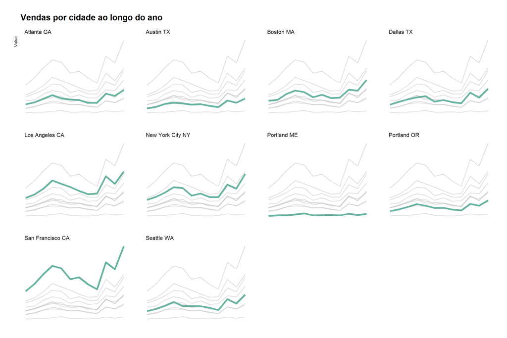

```r
venda.cidade.mes = aggregate(Value ~(City+month),dados,sum)

venda.cidade.mes$month = as.numeric(venda.cidade.mes$month)

tmp <- venda.cidade.mes %>%
  mutate(City2=City)

tmp %>%
  ggplot( aes(x=month, y=Value)) +
    geom_line( data=tmp %>% dplyr::select(-City), aes(group=City2), color="grey", size=0.8, alpha=0.5) +
    geom_line( aes(color=City), color="#69b3a2", size=1.8 )+
    scale_color_viridis(discrete = TRUE) +
    theme_ipsum(base_family= "Calibri",grid = FALSE) +
    theme(
      legend.position="none",
      plot.title = element_text(size=18),
      axis.title.x = element_blank(),
      axis.text.x = element_blank(),
      axis.text.y = element_blank()
      ) +
    ggtitle("Vendas por cidade ao longo do ano") +
    facet_wrap(~City)
```

Podemos observar o mesmo comportamento em todas as cidades: as vendas sobem de janeiro a abril e depois caem até o fim de setembro, antes de voltarem a subir rapidamente.

### Quais produtos são mais frequentemente vendidos juntos?

Primeiro precisamos reunir as vendas por ID e acrescentar os produtos. Mas antes, vamos verificar se existem linhas iguais:

```r
dados[duplicated(dados) | duplicated(dados, fromLast=TRUE),]
```

|  | Order.ID | Product | Quantity.Ordered | Price.Each | Order.Date | Purchase.Address | Value | month | Hour | Date | City |
| --- | --- | --- | --- | --- | --- | --- | --- | --- | --- | --- | --- |
| 31 | 176585 | Bose SoundSport Headphones | 1 | 99.99 | 04/07/19 11:31 | 823 Highland St, Boston, MA 02215 | 99.99 | 04 | 11 | 2019-04-07 | Boston MA |
| 32 | 176585 | Bose SoundSport Headphones | 1 | 99.99 | 04/07/19 11:31 | 823 Highland St, Boston, MA 02215 | 99.99 | 04 | 11 | 2019-04-07 | Boston MA |
| 1302 | 177795 | Apple Airpods Headphones | 1 | 150.00 | 04/27/19 19:45 | 740 14th St, Seattle, WA 98101 | 150.00 | 04 | 19 | 2019-04-27 | Seattle WA |
| 1303 | 177795 | Apple Airpods Headphones | 1 | 150.00 | 04/27/19 19:45 | 740 14th St, Seattle, WA 98101 | 150.00 | 04 | 19 | 2019-04-27 | Seattle WA |
| 1683 | 178158 | USB-C Charging Cable | 1 | 11.95 | 04/28/19 21:13 | 197 Center St, San Francisco, CA 94016 | 11.95 | 04 | 21 | 2019-04-28 | San Francisco CA |
| 1685 | 178158 | USB-C Charging Cable | 1 | 11.95 | 04/28/19 21:13 | 197 Center St, San Francisco, CA 94016 | 11.95 | 04 | 21 | 2019-04-28 | San Francisco CA |
| 3805 | 180207 | Apple Airpods Headphones | 1 | 150.00 | 04/13/19 01:46 | 196 7th St, Los Angeles, CA 90001 | 150.00 | 04 | 01 | 2019-04-13 | Los Angeles CA |
| 3806 | 180207 | Apple Airpods Headphones | 1 | 150.00 | 04/13/19 01:46 | 196 7th St, Los Angeles, CA 90001 | 150.00 | 04 | 01 | 2019-04-13 | Los Angeles CA |
| 4196 | 180576 | Lightning Charging Cable | 1 | 14.95 | 04/18/19 17:23 | 431 Park St, Dallas, TX 75001 | 14.95 | 04 | 17 | 2019-04-18 | Dallas TX |
| 4197 | 180576 | Lightning Charging Cable | 1 | 14.95 | 04/18/19 17:23 | 431 Park St, Dallas, TX 75001 | 14.95 | 04 | 17 | 2019-04-18 | Dallas TX |

[output cut: 518 more lines]

```r
#remove linhas cujos IDs e Produtos sejam iguais e associa a um novo datta frame

venda.id <-
  dados %>%
  distinct(Order.ID,Product, .keep_all=FALSE)
```

Agora, vamos usar a função *count* do pacote dplyr para criar um novo data frame com a frequência dos níveis.

```r
library(dplyr)

id = count(venda.id, Order.ID)
head(id)
```

|  | Order.ID | n |
| --- | --- | --- |
| 1 | 141234 | 1 |
| 2 | 141235 | 1 |
| 3 | 141236 | 1 |
| 4 | 141237 | 1 |
| 5 | 141238 | 1 |
| 6 | 141239 | 1 |

```r
#seleciona apenas os ID's cuja frequência é maior que um, como queríamos
id= id %>%
  filter(n>1)

head(id)
```

|  | Order.ID | n |
| --- | --- | --- |
| 1 | 141275 | 2 |
| 2 | 141290 | 2 |
| 3 | 141365 | 2 |
| 4 | 141384 | 2 |
| 5 | 141450 | 2 |
| 6 | 141457 | 2 |

E então podemos usar o objeto id para atualizar o data frame venda.id

```r
venda.id = venda.id %>%

   filter(Order.ID %in% id$Order.ID  )

head(venda.id,20)
```

|  | Order.ID | Product |
| --- | --- | --- |
| 1 | 176560 | Google Phone |
| 2 | 176560 | Wired Headphones |
| 3 | 176574 | Google Phone |
| 4 | 176574 | USB-C Charging Cable |
| 5 | 176586 | AAA Batteries (4-pack) |
| 6 | 176586 | Google Phone |
| 7 | 176672 | Lightning Charging Cable |
| 8 | 176672 | USB-C Charging Cable |
| 9 | 176681 | Apple Airpods Headphones |
| 10 | 176681 | ThinkPad Laptop |

[output cut: 10 more lines]

Note que agora todos os ID’s aparecem no mínimo duas vezes.

Para fazer a contagem dos pares mais frequentes utilizamos o código abaixo: *combn(unique(x), 2, paste, collapse=“-”)* encontra as combinações únicas dos produtos e os mostra juntos, *tapply* agrupa por ID e retorna uma lista, *unlist* transforma num vetor e *table* calcula as frequências de cada combinação. Essas frequências são sorteadas em ordem decrescente e *tail* seleciona as 5 maiores.

**Obs:** O código resulta em erro se a variável produto for do tipo factor

```r
teste=venda.id

results = tail(sort(table(unlist(tapply(as.character(teste$Product), teste$Order.ID, FUN=function(x) combn(unique(x), 2, paste, collapse=" and "))))),
           5)


(results)
```

```
##
## Vareebadd Phone and USB-C Charging Cable
##                                      361
##        Google Phone and Wired Headphones
##                                      413
##              iPhone and Wired Headphones
##                                      447
##    Google Phone and USB-C Charging Cable
##                                      985
##      iPhone and Lightning Charging Cable
##                                     1002
```

Podemos ver na tabela acima a contagem dos pares de produtos mais vendidos.